# R Notebook

Abraham Lewis

```r
library(readr)
library(ggplot2)
library(dplyr)
options(scipen=999)
```

This data is from kaggle and is based of the world health orginaztiions morality tool.

No complete count is kept of suicide attempts in the U.S.; however, each year the CDC (Center for diesies control prevention) gathers data from hospitals on non-fatal injuries from self-harm as well as survey data.

```r
 who<-read_csv("who_suicide_statistics.csv")
```

`r`r nrow(who)

```
[1] 43776
```

`r`r ncol(who)

```
[1] 6
```

```r
glimpse(who)
```

```
Observations: 43,776
Variables: 6
$ country     <chr> "Albania", "Albania", "Albania", "Albania", "Albania", "Albania", "Albania", "Albania", "Albania"...
$ year        <int> 1985, 1985, 1985, 1985, 1985, 1985, 1985, 1985, 1985, 1985, 1985, 1985, 1986, 1986, 1986, 1986, 1...
$ sex         <chr> "female", "female", "female", "female", "female", "female", "male", "male", "male", "male", "male...
$ age         <chr> "15-24 years", "25-34 years", "35-54 years", "5-14 years", "55-74 years", "75+ years", "15-24 yea...
$ suicides_no <int> NA, NA, NA, NA, NA, NA, NA, NA, NA, NA, NA, NA, NA, NA, NA, NA, NA, NA, NA, NA, NA, NA, NA, NA, 1...
$ population  <int> 277900, 246800, 267500, 298300, 138700, 34200, 301400, 264200, 296700, 325800, 132500, 21100, 283...
```

```r
select(who, country) %>% unique %>% nrow
```

```
[1] 141
```

```r
unique(who$country)
```

```
  [1] "Albania"                            "Anguilla"                           "Antigua and Barbuda"
  [4] "Argentina"                          "Armenia"                            "Aruba"
  [7] "Australia"                          "Austria"                            "Azerbaijan"
 [10] "Bahamas"                            "Bahrain"                            "Barbados"
 [13] "Belarus"                            "Belgium"                            "Belize"
 [16] "Bermuda"                            "Bolivia"                            "Bosnia and Herzegovina"
 [19] "Brazil"                             "British Virgin Islands"             "Brunei Darussalam"
 [22] "Bulgaria"                           "Cabo Verde"                         "Canada"
 [25] "Cayman Islands"                     "Chile"                              "Colombia"
 [28] "Costa Rica"                         "Croatia"                            "Cuba"
 [31] "Cyprus"                             "Czech Republic"                     "Denmark"
 [34] "Dominica"                           "Dominican Republic"                 "Ecuador"
 [37] "Egypt"                              "El Salvador"                        "Estonia"
 [40] "Falkland Islands (Malvinas)"        "Fiji"                               "Finland"
 [43] "France"                             "French Guiana"                      "Georgia"
```

[output cut: 32 more lines]

141

Speaking at an event on suicide prevention in capital Kabul, Afghanistan Independent Human Rights Commission (AIHRC) Commissioner Qudri Yazdan said while suicides continue to be on the rise in the country, several cases go unreported.

The first being afganistan

`r`r names(wc)

```
 [1] \Country\                            \Region\                             \Population\
 [4] \Area..sq..mi..\                     \Pop..Density..per.sq..mi..\         \Coastline..coast.area.ratio.\
 [7] \Net.migration\                      \Infant.mortality..per.1000.births.\ \GDP....per.capita.\
[10] \Literacy....\                       \Phones..per.1000.\                  \Arable....\
[13] \Crops....\                          \Other....\                          \Climate\
[16] \Birthrate\                          \Deathrate\                          \Agriculture\
[19] \Industry\                           \Service\
```

`r`r unique(wc$Country)

```
  [1] Afghanistan                       Albania                           Algeria
  [4] American Samoa                    Andorra                           Angola
  [7] Anguilla                          Antigua & Barbuda                 Argentina
 [10] Armenia                           Aruba                             Australia
 [13] Austria                           Azerbaijan                        Bahamas, The
 [16] Bahrain                           Bangladesh                        Barbados
 [19] Belarus                           Belgium                           Belize
 [22] Benin                             Bermuda                           Bhutan
 [25] Bolivia                           Bosnia & Herzegovina              Botswana
 [28] Brazil                            British Virgin Is.                Brunei
 [31] Bulgaria                          Burkina Faso                      Burma
 [34] Burundi                           Cambodia                          Cameroon
 [37] Canada                            Cape Verde                        Cayman Islands
 [40] Central African Rep.              Chad                              Chile
 [43] China                             Colombia                          Comoros
```

[output cut: 62 more lines]

KABUL, Afghanistan - Up to 3,000 people are committing suicide in Afghanistan each year, 80 percent of whom are women, an official said Sunday.

The Un’s website and more importantly wikepedia says

195 Countries

54 countries are in Africa 48 in Asia 44 in Europe 33 in Latin America and the Caribbean 14 in Oceania 2 in Northern America No county begins with w or x or y in this data set it is missing yemen. loooking at the data we can see that it doesnt inculde all the countries. most of the countries missing are small counrties (such as lichtenstin or kosovo) or countries in southeast asia Laos or cambodia or in africa (such as chad or mozambque)

Most Importantly its missing india and china. So in the first data set there a numerious countries missing the first bineg afgantant

Or Data that Just isnt collected

`r`r summary(who)

```
   country               year          sex                age             suicides_no        population
 Length:43776       Min.   :1979   Length:43776       Length:43776       Min.   :    0.0   Min.   :     259
 Class :character   1st Qu.:1990   Class :character   Class :character   1st Qu.:    1.0   1st Qu.:   85113
 Mode  :character   Median :1999   Mode  :character   Mode  :character   Median :   14.0   Median :  380655
                    Mean   :1999                                         Mean   :  193.3   Mean   : 1664091
                    3rd Qu.:2007                                         3rd Qu.:   91.0   3rd Qu.: 1305698
                    Max.   :2016                                         Max.   :22338.0   Max.   :43805214
                                                                         NA's   :2256      NA's   :5460
```

`r`r which(!complete.cases(who))

[output not shown]

[output cut: 30 more lines]

`r`r head(who)

| country | year | sex | age | suicides_no | population |
| --- | --- | --- | --- | --- | --- |
| Albania | 1985 | female | 15-24 years | NA | 277900 |
| Albania | 1985 | female | 25-34 years | NA | 246800 |
| Albania | 1985 | female | 35-54 years | NA | 267500 |
| Albania | 1985 | female | 5-14 years | NA | 298300 |
| Albania | 1985 | female | 55-74 years | NA | 138700 |
| Albania | 1985 | female | 75+ years | NA | 34200 |

`r`r c1<- who%>% group_by(country) %>% summarise(total_suicides = sum(suicides_no,na.rm=TRUE)) %>% arrange(desc(total_suicides))

`r`r c1

| country | total_suicides |
| --- | --- |
| Russian Federation | 1500992 |
| United States of America | 1201401 |
| Japan | 937614 |
| France | 395500 |
| Ukraine | 365170 |
| Germany | 291262 |
| Republic of Korea | 261730 |
| Brazil | 250824 |
| Poland | 172562 |
| United Kingdom | 166314 |

[output cut: 131 more lines]

From this I saw that about half the countries had a suicide total over 10000 then went down all the way to Montserrat which had 1 also another fact was that about 70 percent of the countries had at least 5 years of usable data recorded.

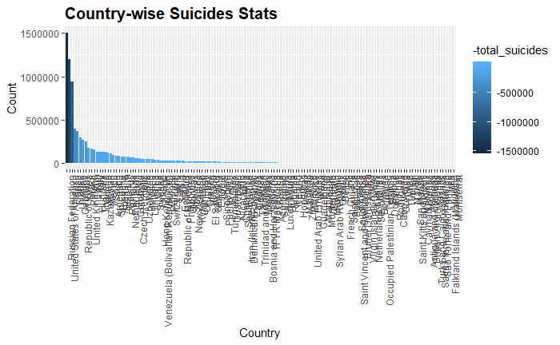

So with the first attept to look at the data it was a mess so I decided to just look at countries in terms of age and gender with regards to suicide.

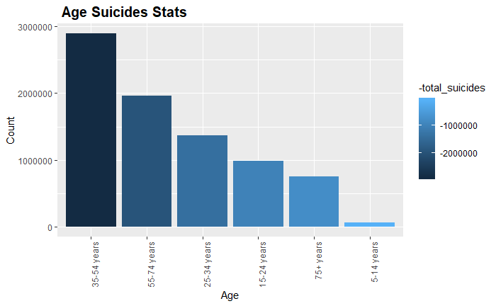

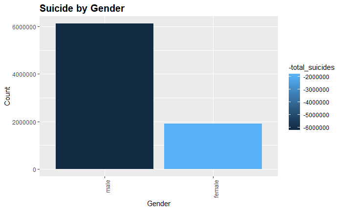

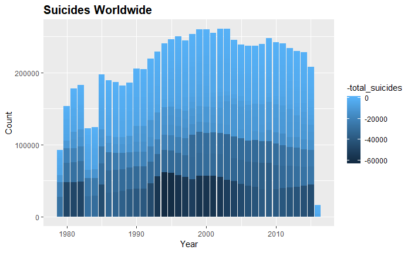

Then to make things clearer I looked at the top ten countries.

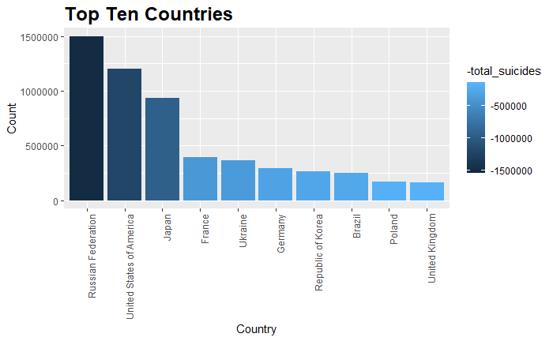

```r
df_top10 <- who %>%
  filter( (country== "Russian Federation")| (country== "United States of America") | (country=="Japan")| (country=="France")|  (country== "Ukraine") |(country=="Germany") |(country=="Republic of Korea")|(country=="Brazil")|(country== "United Kingdom")| (country== "Poland")   )
```

`r`r whoDF_10 <- df_top10 %>% group_by(year,country) %>% summarise(total_suicides = sum(suicides_no,na.rm=TRUE)) %>% arrange(desc(total_suicides)) ggplot(whoDF_10,mapping = aes(x=year, y=total_suicides, colour = country)) +geom_line(aes(linetype = country))

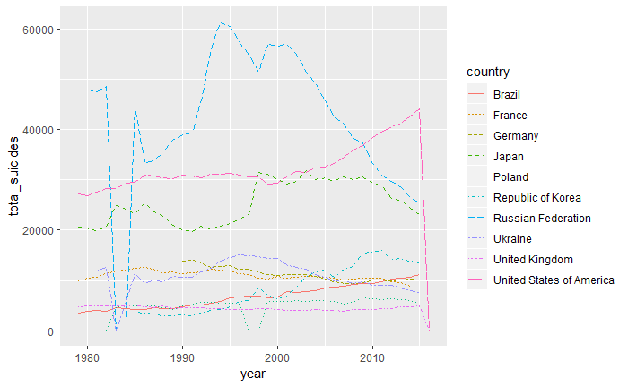

`r`r hop <- df7 %>% group_by(year,country) %>% summarise(total_suicides = sum(suicides_no,na.rm=TRUE)) %>% arrange(desc(total_suicides)) ggplot(data = hop, mapping = aes(x =country , y = total_suicides)) + geom_boxplot() + coord_flip()

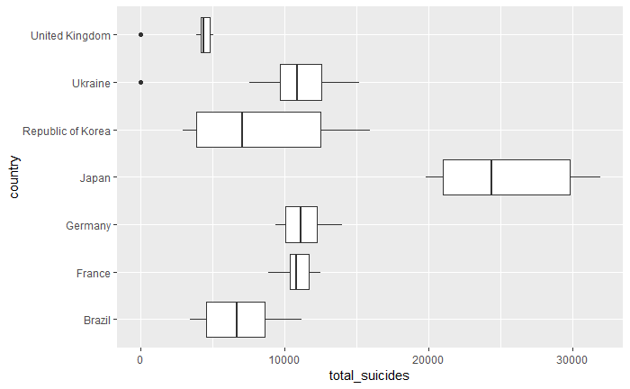

While Russia and the USA had the highest sum of suicides another important way to look at this issue is with the ratio of population.

`r`r df_country_group <- who %>% group_by(country) %>% summarise(sumsui= sum( as.numeric(suicides_no)),popsum = sum(as.numeric(population))) df_country_group <- na.omit(df_country_group) df_country_group_ratio<- df_country_group %>% mutate(ratioSP =sumsui/popsum) df_country_group_ratio <- df_country_group_ratio %>% arrange(-ratioSP) df_country_group_ratio_top <- head(df_country_group_ratio,10)

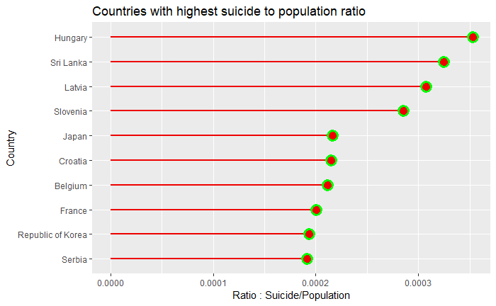

```r
sum(who$suicides_no,na.rm=TRUE)
```

[output not shown]

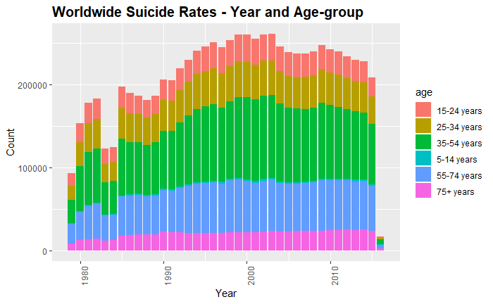

What one sees is that there is spike in the late 90’s then a slight decrease and increase around 2007-2008 then a continued decrease.

I wanted to finally compare the 2 countries with highest suicide by sum, the USA and Russia.

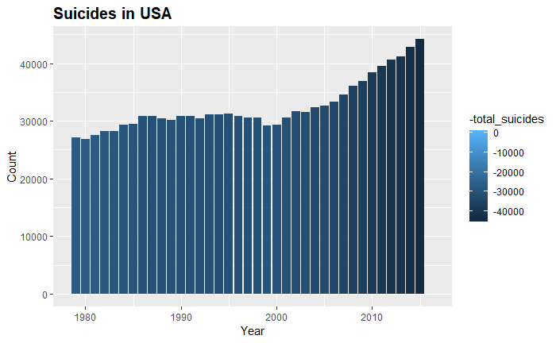

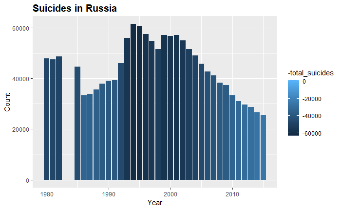

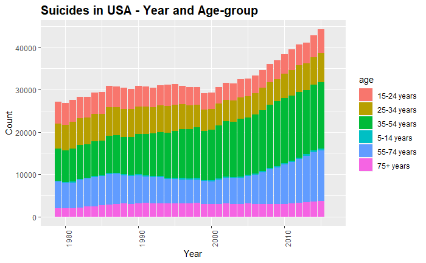

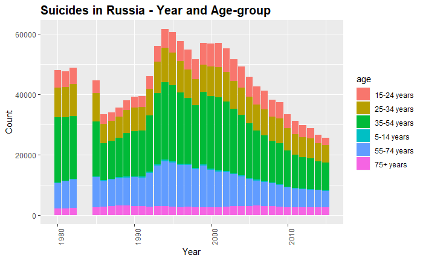

[figure not shown]

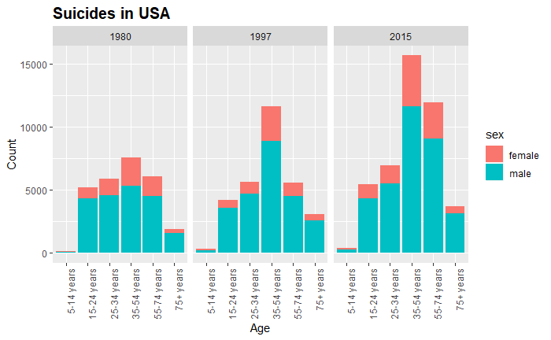

In 2015, 505,507 people visited a hospital for injuries due to self-harm. This number suggests that for every reported suicide death, approximately 11.4 people visit a hospital for self-harm related injuries. However, because of the way these data are collected, we are not able to distinguish intentional suicide attempts from non-intentional self-harm behaviors.

Based on the 2016 National Survey of Drug Use and Mental Health it is estimated that 0.5 percent of the adults aged 18 or older made at least one suicide attempt. This translates to approximately 1.3 million adults. Adult females reported a suicide attempt 1.2 times as often as males. Further breakdown by gender and race are not available.

Based on the 2015 Youth Risk Behaviors Survey, 8.6 percent of youth in grades 9-12 reported that they had made at least one suicide attempt in the past 12 months. Girls attempted twice as often as boys (11.6% vs. 5.5%) and teens of Hispanic origin reported the highest rate of attempt (11.3%), especially Hispanic females (15.1%) when compared with white students (6.8%) and White females (9.8%). Approximately 2.8 percent reported making a suicide attempt that required treatment by a doctor or nurse. For those requiring treatment, rates were highest for Hispanic students with black males (4.0%) and Hispanic males (2.9%) having higher rates than white male (0.9%) students.

When it comes to suicide and suicide attempts there are rate differences depending on demographic characteristics such as age, gender, ethnicity and race. Nonetheless, suicide occurs in all demographic groups.

American foundation for for prevention of suicide

In conclusion Suicide is epidemic with a large amount of causes but a dearth of solutions. There needs to be more reaserch conducted on the subject.